# EDA

## Задача

- Анализ содержания загрязняющих веществ в водных объектах

### Описание

- **В ежемесячном режиме** осуществляется мониторинг содержания загрязняющих веществ в водных объектах Тюменской области в части выявления превышений предельных допустимых концентраций по сведениям, предоставленным Тюменским центром по гидрометеорологии и мониторингу окружающей среды – филиалом ФГБУ «Обь-Иртышское управление по гидрометеорологии и мониторингу окружающей среды»

# "ежемесячном" 😢

### Критерии решения

- По итогам обработки данных сервисом получена информация, позволяющая сделать выводы: о наиболее чистых и загрязненных водных объектах в разное время года, о веществах, превышение которых наблюдается регулярно о динамике загрязненности водных объектов

### Гипотезы задачи:

- Превышение предельных допустимых концентраций загрязняющих веществ (каждого в отдельности и всех в совокупности) наблюдается:
  - ежегодно в одно и тоже время
  - вне зависимости от времени года
  - загрязнение ряда водных объектов имеют одинаковый состав загрязняющих веществ
  - наблюдается ежегодная динамику увеличения/уменьшения загрязненности водных объектов
  - **в зависимости от дня недели**

# Содержание работы:

### 1. Загрузка библиотек и данных

### 2. Базовый анализ датасета:

- **Размер датасета**
- **Типы данных**
- **Состав признаков**

### 3. Анализ признаков и предобработка данных

- **Наименование водного объекта**
- **Азот нитритный**

### 4. Текущие выводы

### 5. TODO

### Загрузка библиотек и данных

```python
import pandas as pd
import numpy as np
from matplotlib import pyplot as plt
from IPython.display import display
import re

import seaborn as sns
sns.set(style="whitegrid")
```

```python
data = pd.read_csv('7202136720.76.2.csv', encoding='cp1251', sep=';', index_col='Период наблюдений',
                   decimal=',', na_values=' ', parse_dates=True, dayfirst=True)
```

### Размер датасета

```python
print('Размер датасета:', data.shape)
```

```
Размер датасета: (666, 14)
```

> **В проработку:**

> Количество наблюдений в датасете не по фен Шую, требуется удалить лишнюю строку или строки. Для минимизации потери информации, выберем строки с максимальным количеством пропущенных значений.

```python
max_nas = data.isna().sum(axis=1).max()
idx = np.where(data.isna().sum(axis=1) == max_nas)[0]
print(f'Максимальное количество пропусков в строке: {max_nas}, количество таких записей {len(idx)}')
print('\nСтроки для удаления:')
display(data.iloc[idx])
data = data[~data.index.isna()]
print('\nРазмер скорректированного датасета:', data.shape, 'удаленная строка не имела никакой полезной информации')
```

```
Максимальное количество пропусков в строке: 12, количество таких записей 1

Строки для удаления:
```

| Период наблюдений | Номер | Наименование водного объекта | Азот нитритный | Азот аммонийный | Азот нитратный | Фенол | Нефтепродукты | Органические вещества (по ХПК) | Железо | Медь | Цинк | Марганец | БПК5 | Дата модификации |
| --- | --- | --- | --- | --- | --- | --- | --- | --- | --- | --- | --- | --- | --- | --- |
| NaT | 627 | NaN | NaN | NaN | NaN | NaN | NaN | NaN | NaN | NaN | NaN | NaN | NaN | 13.12.2019 10:01:14 |

```
Размер скорректированного датасета: (665, 14) удаленная строка не имела никакой полезной информации
```

> **Результат**:

> Теперь, когда с коварным планом человека, подготавливающего датасет - покончено (**+1 к карме**), можно приступить к рассмотрению типов данных

### Типы данных

```python
data.dtypes
```

```
Номер                              int64
Наименование водного объекта      object
Азот нитритный                    object
Азот аммонийный                   object
Азот нитратный                    object
Фенол                             object
Нефтепродукты                     object
Органические вещества (по ХПК)    object
Железо                            object
Медь                              object
Цинк                              object
Марганец                          object
БПК5                              object
Дата модификации                  object
dtype: object
```

> **Инфо:**

### Состав признаков

```python
data.describe(include='all').T
```

|  | count | unique | top | freq | mean | std | min | 25% | 50% | 75% | max |
| --- | --- | --- | --- | --- | --- | --- | --- | --- | --- | --- | --- |
| Номер | 665 | NaN | NaN | NaN | 333.059 | 192.209 | 1 | 167 | 333 | 499 | 666 |
| Наименование водного объекта | 665 | 25 | р. Тобол, в створе с. Коркино, превышение ПДК | 49 | NaN | NaN | NaN | NaN | NaN | NaN | NaN |
| Азот нитритный | 665 | 37 | в пределах нормы | 431 | NaN | NaN | NaN | NaN | NaN | NaN | NaN |
| Азот аммонийный | 665 | 26 | в пределах нормы | 324 | NaN | NaN | NaN | NaN | NaN | NaN | NaN |
| Азот нитратный | 661 | 1 | в пределах нормы | 661 | NaN | NaN | NaN | NaN | NaN | NaN | NaN |
| Фенол | 665 | 10 | в пределах нормы | 359 | NaN | NaN | NaN | NaN | NaN | NaN | NaN |
| Нефтепродукты | 665 | 25 | в пределах нормы | 362 | NaN | NaN | NaN | NaN | NaN | NaN | NaN |
| Органические вещества (по ХПК) | 665 | 3 | - | 406 | NaN | NaN | NaN | NaN | NaN | NaN | NaN |
| Железо | 39 | 2 | Выше ПДК | 21 | NaN | NaN | NaN | NaN | NaN | NaN | NaN |
| Медь | 39 | 2 | Выше ПДК | 38 | NaN | NaN | NaN | NaN | NaN | NaN | NaN |
| Цинк | 35 | 1 | В пределах нормы | 35 | NaN | NaN | NaN | NaN | NaN | NaN | NaN |
| Марганец | 39 | 1 | Выше ПДК | 39 | NaN | NaN | NaN | NaN | NaN | NaN | NaN |
| БПК5 | 35 | 2 | В пределах нормы | 29 | NaN | NaN | NaN | NaN | NaN | NaN | NaN |
| Дата модификации | 665 | 665 | 27.11.2019 17:31:56 | 1 | NaN | NaN | NaN | NaN | NaN | NaN | NaN |

> **Инфо**:

> Имеется информация о пробах, собираемых в 25 разных точках

> Данные по содержанию Железа, Меди, Цинка, Марганца, БПК5 имеют 35-39 записей. По остальным пробам 661-665 записей

> Железо, Медь и БПК5 имеют по 2 уникальных значения. Органические вещества (по ХПК) - 3 уникальных значения

> Для Азота нитратного, Цинка и Марганца помимо пропусков существует только одно уникальное значение:

> ```
> * Все пробы Азота нитратного и Цинка - в пределах нормы
> * Все пробы Марганца - выше ПДК
> ```

> **В проработку**:

> Прогнозирование и анализ неизменяемых параметров, дело не благодарное и на текущий момент эти параметры можно удалить. Возможно данные параметры будут полезны при комбинации признаков, но для этого требуется ознакомление с предметной областью

> Признак "Номер" так же не несет никакой полезной информации

```python
data = data.drop(columns=['Азот нитратный', 'Цинк', 'Марганец', 'Номер'])
display(data.head(3))
display(data.tail(3))
```

| Период наблюдений | Наименование водного объекта | Азот нитритный | Азот аммонийный | Фенол | Нефтепродукты | Органические вещества (по ХПК) | Железо | Медь | БПК5 | Дата модификации |
| --- | --- | --- | --- | --- | --- | --- | --- | --- | --- | --- |
| 2015-01-20 | р. Тура, в створе с. Салаирка, ПДК | 1,5 | 1,6 | 6,0 | в пределах нормы | - | NaN | NaN | NaN | 27.02.2015 15:16:55 |
| 2015-01-20 | р. Тура, выше г. Тюмени, ПДК | в пределах нормы | 1,5 | 4,0 | в пределах нормы | - | NaN | NaN | NaN | 27.02.2015 15:15:08 |
| 2015-01-20 | р. Тура, ниже г. Тюмени, ПДК | в пределах нормы | 2,1 | в пределах нормы | в пределах нормы | - | NaN | NaN | NaN | 27.02.2015 15:14:32 |

| Период наблюдений | Наименование водного объекта | Азот нитритный | Азот аммонийный | Фенол | Нефтепродукты | Органические вещества (по ХПК) | Железо | Медь | БПК5 | Дата модификации |
| --- | --- | --- | --- | --- | --- | --- | --- | --- | --- | --- |
| 2020-03-20 | р. Тобол, в створе с. Коркино, превышение ПДК | в пределах нормы | Выше ПДК | Выше ПДК | Выше ПДК | Выше нормы | В пределах нормы | Выше ПДК | В пределах нормы | 21.04.2020 12:37:19 |
| 2020-03-20 | р. Тобол, выше г. Ялуторовска, превышение ПДК | Выше ПДК | Выше ПДК | в пределах нормы | Выше ПДК | Выше нормы | В пределах нормы | Выше ПДК | В пределах нормы | 21.04.2020 12:38:31 |
| 2020-03-20 | р. Тобол, ниже г. Ялуторовска, превышение ПДК | Выше ПДК | Выше ПДК | Выше ПДК | Выше ПДК | Выше нормы | В пределах нормы | Выше ПДК | В пределах нормы | 21.04.2020 12:40:00 |

> **Инфо:**

> Некоторые признаки имеют как числовые, так бинарные (в пределах нормы/Выше ПДК) значения

> Наименование водного объекта включает в себя название реки, описание места отбора и приписку ПДК/превышение ПДК (разделенные запятой)

> **В проработку:**

> Добавить признаки: название реки и место отбора и ПДК

## Анализ признаков

### Наименование водного объекта

- Добавление и анализ следующих признаков:
  - название реки
  - место отбора
  - ПДК

```python
data['Река'] = data['Наименование водного объекта'].apply(lambda x: x.split(',')[0])
data['Точка отбора'] = data['Наименование водного объекта'].apply(lambda x: x.split(',')[1])
data['ПДК'] = data['Наименование водного объекта'].apply(lambda x: x.split(',')[2])
```

```python
display(data['Река'].value_counts().to_frame())
display(data.groupby('Река')['Точка отбора'].value_counts().to_frame())
```

|  | Река |
| --- | --- |
| р. Тобол | 222 |
| р. Ишим | 222 |
| р. Тура | 221 |

| Река | Точка отбора | Точка отбора |
| --- | --- | --- |
| р. Ишим | в створе с. Ильинское | 64 |
|  | выше г. Ишима | 64 |
|  | ниже г. Ишима | 64 |
|  | в створе с. Абатское | 30 |
| р. Тобол | ниже г. Ялуторовска | 65 |
|  | в створе с. Коркино | 64 |
|  | выше г. Ялуторовска | 64 |
|  | в створе с. Иевлево | 24 |
|  | с. Иевлево | 5 |
| р. Тура | в створе с. Салаирка | 64 |
|  | выше г. Тюмени | 64 |
|  | ниже г. Тюмени | 64 |
|  | в створе с. Покровское | 29 |

> **Инфо:**

> В датасете присутствуют данные по трем рекам: Тобол, Ишим, Тура

> Количество данных по всем рекам можно считать одинаковым

> Ишим и Тура имеют по 4 точки отбора, Тобол - 5

> Максимальное количество проб на одну точку отбора 64-65

> **В проработку:**

> Проверить, бывают ли одинаковые названия точек отбора для разных рек

```python
pd.crosstab(data['Река'], data['Точка отбора']).T
```

| Река Точка отбора | р. Ишим | р. Тобол | р. Тура |
| --- | --- | --- | --- |
| в створе с. Абатское | 30 | 0 | 0 |
| в створе с. Иевлево | 0 | 24 | 0 |
| в створе с. Ильинское | 64 | 0 | 0 |
| в створе с. Коркино | 0 | 64 | 0 |
| в створе с. Покровское | 0 | 0 | 29 |
| в створе с. Салаирка | 0 | 0 | 64 |
| выше г. Ишима | 64 | 0 | 0 |
| выше г. Тюмени | 0 | 0 | 64 |
| выше г. Ялуторовска | 0 | 64 | 0 |
| ниже г. Ишима | 64 | 0 | 0 |
| ниже г. Тюмени | 0 | 0 | 64 |
| ниже г. Ялуторовска | 0 | 65 | 0 |
| с. Иевлево | 0 | 5 | 0 |

> **Инфо:**

> Названия точек отбора у разных рек не пересекаются.

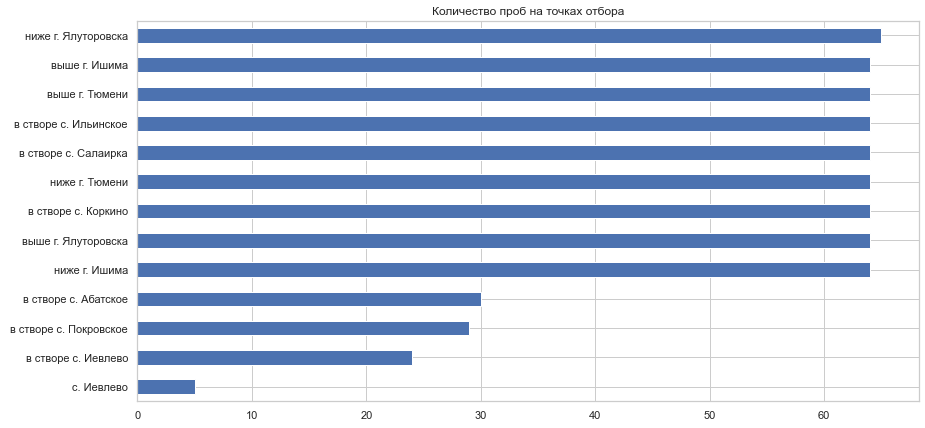

```python
data['Точка отбора'].value_counts().sort_values().plot(kind='barh', figsize=(14, 7))
plt.title('Количество проб на точках отбора');
```

```python
display(data['ПДК'] .value_counts().to_frame())
```

|  | ПДК |
| --- | --- |
| превышение ПДК | 515 |
| ПДК | 150 |

> **В проработку:**

> Проверить, есть ли отличия между наблюдениями с записью ПДК и превышение ПДК

> **Инфо:**

> Датасет небольшой, я проверил его глазами в excel. Нашел следующее:
> - ПДК - иногда встречаются вещественные значения
> - превышение ПДК - только категориальные признаки

### Азот нитритный

```python
data['Азот нитритный'].value_counts()
```

```
в пределах нормы    431
Выше ПДК            163
выше ПДК              8
1,9                   6
1,3                   4
2,0                   4
2,5                   4
2,3                   3
2,1                   3
2,7                   3
1,7                   3
1,4                   2
3,2                   2
1,2                   2
1,1                   2
```

[output cut: 23 more lines]

> **В проработку:**

> В данных есть одинаковые слова написанные с разным регистром (например Выше ПДК/ выше ПДК). Требуется приведение всех слов к нижнему регистру

> Вещественные значения надо обрабатывать отдельно, при этом следует заменить "," на "."

```python
# Приведение к нижнему регистру
data = data.apply(lambda x: x.fillna('').apply(lambda x: x.lower())).replace('', np.NaN)
```

```python
# Функция для создания признака содержащего вещественные значения

def select_numeric_values(data, column):
    df = data.copy()
    df['float_' + column] = data[column].apply(lambda x: (re.sub('[^0-9\.]', '', x.replace(',', '.'))))
    df['float_' + column] = df['float_' + column].replace('', np.NaN).astype(float)
    return df
```

```python
data = select_numeric_values(data, 'Азот нитритный')
data[['Азот нитритный',  'float_Азот нитритный']].head()
```

| Период наблюдений | Азот нитритный | float_Азот нитритный |
| --- | --- | --- |
| 2015-01-20 | 1,5 | 1.5 |
| 2015-01-20 | в пределах нормы | NaN |
| 2015-01-20 | в пределах нормы | NaN |
| 2015-01-20 | 1,7 | 1.7 |
| 2015-01-20 | 2,0 | 2.0 |

```python
pd.crosstab(data['Точка отбора'], ~data['float_Азот нитритный'].isna()).rename(columns={False: 'Строковые значения',
                                                                                        True: 'Числовые значения'})
```

| float_Азот нитритный Точка отбора | Строковые значения | Числовые значения |
| --- | --- | --- |
| в створе с. абатское | 30 | 0 |
| в створе с. иевлево | 24 | 0 |
| в створе с. ильинское | 56 | 8 |
| в створе с. коркино | 57 | 7 |
| в створе с. покровское | 28 | 1 |
| в створе с. салаирка | 59 | 5 |
| выше г. ишима | 61 | 3 |
| выше г. тюмени | 61 | 3 |
| выше г. ялуторовска | 53 | 11 |
| ниже г. ишима | 56 | 8 |
| ниже г. тюмени | 58 | 6 |
| ниже г. ялуторовска | 54 | 11 |
| с. иевлево | 5 | 0 |

> **Инфо:**

> Наибольшее количество записей содержащих числовые значения по Азоту нитритному у точек отбора выше г. Ялуторовска и ниже г. Ялуторовска по 11 проб на каждую точку

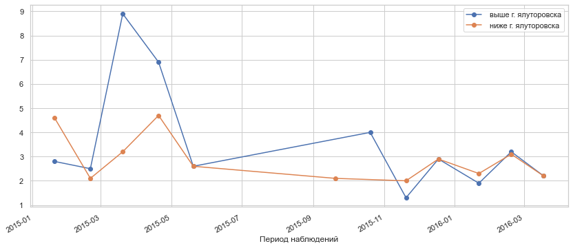

```python
for point in data['Точка отбора'].unique():
    df = data.copy()[data['Точка отбора'] == point]
    df = df[~df['float_Азот нитритный'].isna()]
    if df.shape[0] == 11:
        df['float_Азот нитритный'].plot(label=point, figsize=(14, 6), marker='o')
    else:
        continue

    plt.legend()
```

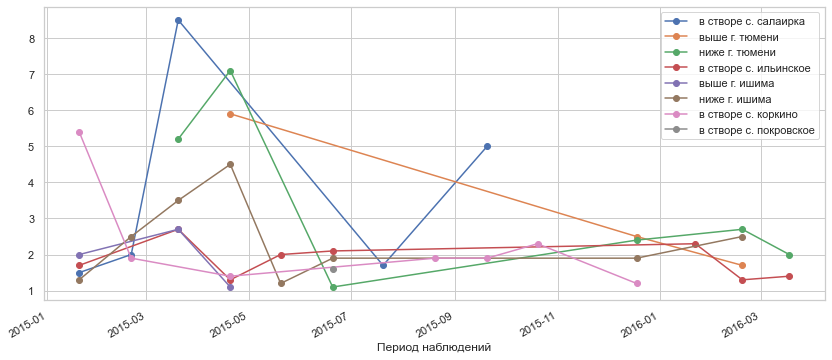

```python
for point in data['Точка отбора'].unique():
    df = data.copy()[data['Точка отбора'] == point]
    df = df[~df['float_Азот нитритный'].isna()]
    if (df.shape[0] > 0) & (df.shape[0] < 11):
        df['float_Азот нитритный'].plot(label=point, figsize=(14, 6), marker='o')
    else:
        continue

    plt.legend()
```

> **Инфо**

> По предыдущим графикам выделить какую-то полезную информацию не удалось

```python
description_dict = {'в пределах нормы': 0, 'выше пдк':1}
temp_df = data[data['Азот нитритный'].isin(['в пределах нормы', 'выше пдк'])]
temp_df['Азот нитритный'] = temp_df['Азот нитритный'].replace(description_dict)
```

> **Инфо:**

> Бинарные признаки не очень хорошо смотрятся на графиках, поэтому было использование усреднение со скользящим окном и добавлен разный сдвиг по оси Y для разных точек отбора

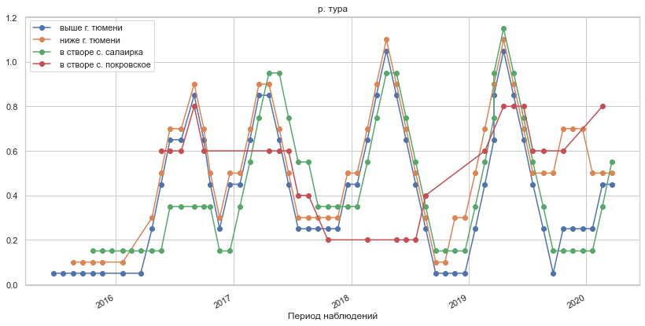

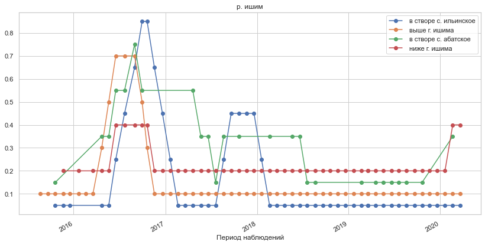

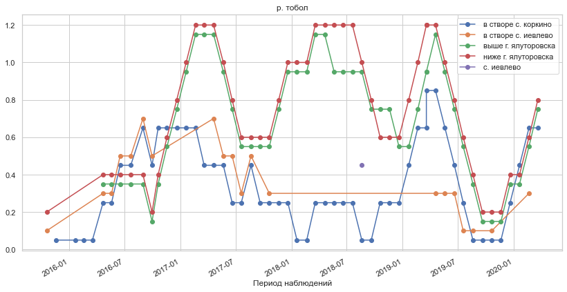

```python
# Для борьбы с наложением линий друг на друга каждой точке отбора будет добавлятся определенный сдвиг по оси Y
shift_step = 0.05

for river in temp_df['Река'].unique():
    mask = temp_df['Река'] == river
    shift = 0
    for point in temp_df[mask]['Точка отбора'].unique():
        shift += shift_step
        df = temp_df.copy()[temp_df['Точка отбора'] == point]
        # Добавлено сглаживание
        (df['Азот нитритный'].rolling(5).mean() + shift).plot(label=point, figsize=(14, 7), marker='o')
        plt.title(river)
    plt.legend()
    plt.show()
```

> **Инфо:**

> На реке Тура все точки отбора за исключением "в створе с.Покровское" показывают похожую динамику по содержанию азота нитритного. Это может быть связано с тем, что "в створе с.Покровское" имеет меньше отобранных проб и при сглаживании со скользящим окном искажается

> На реке Ишим схожей динамики в разных точках выявить не удалось

> На реке Тобол точки отбора выше и ниже города Ялуторовска показывают очень похожую динамику

### Текущие выводы:

- Если задача действительно значимая, то следует задуматься о возможности ежедневного, а возможно и несколько раз в день, отбора проб.
- Желательно фиксировать не только дату, но и время отбора проб
- Если одновременно в одной точке отбора будет собираться несколько проб, то по таким данным можно будет оценить погрешность измерений
- Показания погоды: температура, осадки и влажность, скорость и направление ветра, скорее всего оказывают влияние на содержание веществ в воде и должны быть добавлены к текущему датасету.
- Можно добавить в датасет данные по энергопотреблению Тюменской области или ее отдельных частей
- На реке Тобол точки отбора выше и ниже города Ялуторовска показывают очень похожую динамику, это может быть связанно не только со схожим содержанием веществ, но и с тем, что в районе Ялуторовска пробы отбираются одной бригадой и проверяются одной лабораторией, а для других точек отбора другими бригадами и лабораториями. Процедуры сбора и анализ могут отличаться и как следствие могут отличатся и результаты анализа. Возможно стоит присвоить id номера бригадам по сбору и лабораториям, и дополнять датасет этой информацией.

### TODO

- Анализ всех последующих признаков
- Парсинг данных по погоде (желательно локаций близких к точкам сбора, а не Тюменской области в целом)
- Парсинг данных по энергопотреблению (желательно локаций близких к точкам сбора, а не Тюменской области в целом)